# Introduction to FEDUP

Catherine Ross

FEDUP is an R package that tests for enrichment and depletion of user-defined pathways using a Fisher’s exact test. The method is designed for versatile pathway annotation formats (eg. gmt, txt, xlsx) to allow the user to run pathway analysis on custom annotations. This package is also integrated with Cytoscape to provide network-based pathway visualization that enhances the interpretability of the results.

# Getting started

## System prerequisites

**R version** ≥ 4.0  
**R packages**:

- **CRAN**: openxlsx, tibble, dplyr, data.table, ggplot2, ggthemes, forcats, RColorBrewer
- **Bioconductor**: RCy3

## Installation

Install `FEDUP` via devtools:

```r
devtools::install_github("rosscm/FEDUP")
```

# Running the package

## Sample input

Load test genes (`testGene`), background genes (`backgroudGene`), and pathways (`pathwaysGMT`):

Note, the sample `testGene` object only consists of genes from the pathway `MUSCLE CONTRACTION%REACTOME DATABASE ID RELEASE 74%397014`. So we would expect to see strong **enrichment** for pathways related to muscle contraction and, **depletion** for pathways *not* associated with muscle contraction. Let’s see!

```r
library(FEDUP)
data(testGene)
data(backgroundGene)
data(pathwaysGMT)
```

Take a look at the data structure:

```r
str(testGene)
```

```
#>  chr [1:190] "NKX2-5" "SCN4A" "ITGB5" "SCN4B" "PAK2" "GATA4" "AKAP9" ...
```

```r
str(backgroundGene)
```

```
#>  chr [1:10208] "PCYT1B" "PCYT1A" "PLA2G4D" "PLA2G4B" "PLA2G4C" "PLA2G4A" ...
```

```r
str(head(pathwaysGMT))
```

```
#> List of 6
#>  $ REGULATION OF PLK1 ACTIVITY AT G2 M TRANSITION%REACTOME%R-HSA-2565942.1          : chr [1:84] "CSNK1E" "DYNLL1" "TUBG1" "CKAP5" ...
#>  $ GLYCEROPHOSPHOLIPID BIOSYNTHESIS%REACTOME%R-HSA-1483206.4                        : chr [1:126] "PCYT1B" "PCYT1A" "PLA2G4D" "PLA2G4B" ...
#>  $ MITOTIC PROPHASE%REACTOME DATABASE ID RELEASE 74%68875                           : chr [1:134] "SETD8" "NUMA1" "NCAPG2" "LMNB1" ...
#>  $ ACTIVATION OF NF-KAPPAB IN B CELLS%REACTOME%R-HSA-1169091.1                      : chr [1:67] "PSMA6" "PSMA3" "PSMA4" "PSMA1" ...
#>  $ CD28 DEPENDENT PI3K AKT SIGNALING%REACTOME DATABASE ID RELEASE 74%389357         : chr [1:22] "CD28" "THEM4" "AKT1" "TRIB3" ...
#>  $ UBIQUITIN-DEPENDENT DEGRADATION OF CYCLIN D%REACTOME DATABASE ID RELEASE 74%75815: chr [1:52] "PSMA6" "PSMA3" "PSMA4" "PSMA1" ...
```

Now use `runFedup` on sample data:

```r
fedupRes <- runFedup(testGene, backgroundGene, pathwaysGMT)
```

```
#> Data input:
#>  => 190 test genes
#>  => 10208 background genes
#>  => 1437 pathawys
#> You did it! FEDUP ran successfully, feeling pretty good huh?
```

View output results table sorted by pvalue:

```r
print(head(fedupRes[which(fedupRes$status == "Enriched"),]))
```

```
#>                                                             pathway size
#> 1:        MUSCLE CONTRACTION%REACTOME DATABASE ID RELEASE 74%397014  190
#> 2:       CARDIAC CONDUCTION%REACTOME DATABASE ID RELEASE 74%5576891  124
#> 3:                         ION HOMEOSTASIS%REACTOME%R-HSA-5578775.2   51
#> 4: SMOOTH MUSCLE CONTRACTION%REACTOME DATABASE ID RELEASE 74%445355   37
#> 5:              STRIATED MUSCLE CONTRACTION%REACTOME%R-HSA-390522.1   34
#> 6:          PHASE 0 - RAPID DEPOLARISATION%REACTOME%R-HSA-5576892.2   31
#>    real_frac expected_frac fold_enrichment   status
#> 1: 100.00000     1.8612853        53.72632 Enriched
#> 2:  65.26316     1.2147335        53.72632 Enriched
#> 3:  26.84211     0.4996082        53.72632 Enriched
#> 4:  19.47368     0.3624608        53.72632 Enriched
#> 5:  17.89474     0.3330721        53.72632 Enriched
#> 6:  16.31579     0.3036834        53.72632 Enriched
#>                                     real_gene        pvalue        qvalue
#> 1:    NKX2-5,SCN4A,ITGB5,SCN4B,PAK2,GATA4,... 1.091522e-189 1.568518e-186
#> 2:  NKX2-5,SCN4A,SCN4B,GATA4,AKAP9,KCNJ14,... 4.477692e-130 3.217222e-127
#> 3:     SLN,STIM1,ORAI2,ORAI1,ABCC9,KCNJ11,...  1.513045e-57  7.247487e-55
#> 4:       ITGB5,PAK2,ACTA2,VCL,MYL12B,MYL6,...  1.161897e-42  4.174116e-40
#> 5:           VIM,TNNI3,DMD,TPM4,TPM3,TPM2,...  2.009234e-39  5.774540e-37
#> 6: SCN4A,SCN4B,SCN7A,SCN11A,SCN10A,CACNG6,...  3.621270e-36  8.672941e-34
```

```r
print(head(fedupRes[which(fedupRes$status == "Depleted"),]))
```

```
#>                                                                                               pathway
#> 1:                                 OLFACTORY SIGNALING PATHWAY%REACTOME DATABASE ID RELEASE 74%381753
#> 2:                         AMINO ACID AND DERIVATIVE METABOLISM%REACTOME DATABASE ID RELEASE 74%71291
#> 3:                                                                  DNA REPAIR%REACTOME%R-HSA-73894.3
#> 4:                                                        GPCR LIGAND BINDING%REACTOME%R-HSA-500792.3
#> 5: ANTIGEN PROCESSING: UBIQUITINATION & PROTEASOME DEGRADATION%REACTOME DATABASE ID RELEASE 74%983168
#> 6:                           ASPARAGINE N-LINKED GLYCOSYLATION%REACTOME DATABASE ID RELEASE 74%446203
#>    size real_frac expected_frac fold_enrichment   status real_gene      pvalue
#> 1:  396 0.0000000      3.879310       0.0000000 Depleted           0.001390230
#> 2:  368 0.0000000      3.605016       0.0000000 Depleted           0.002073172
#> 3:  329 0.0000000      3.222962       0.0000000 Depleted           0.004692174
#> 4:  454 0.5263158      4.447492       0.1183399 Depleted     ANXA1 0.005238539
#> 5:  308 0.0000000      3.017241       0.0000000 Depleted           0.007054720
#> 6:  286 0.0000000      2.801724       0.0000000 Depleted           0.010568697
#>        qvalue
#> 1: 0.02853944
#> 2: 0.04081024
#> 3: 0.08505496
#> 4: 0.09293556
#> 5: 0.11926627
#> 6: 0.17258203
```

Here we see the strongest enrichment for the `MUSCLE CONTRACTION` pathway. Since our test set of genes are exclusively from this pathway, this is totally expected. We also see significant enrichment for other muscle contraction pathways, including `CARDIAC CONDUCTION` and `SMOOTH MUSCLE CONTRACTION`. Conversely, we see significant depletion for functions not associated with muscle contraction, such as `OLFACTORY SIGNALING PATHWAY` and `AMINO ACID AND DERIVATIVE METABOLISM`. Nice!

Plot enriched and depleted pathways (qvalue < 0.05) in the form of a dot plot via the `plotDotPlot` function:

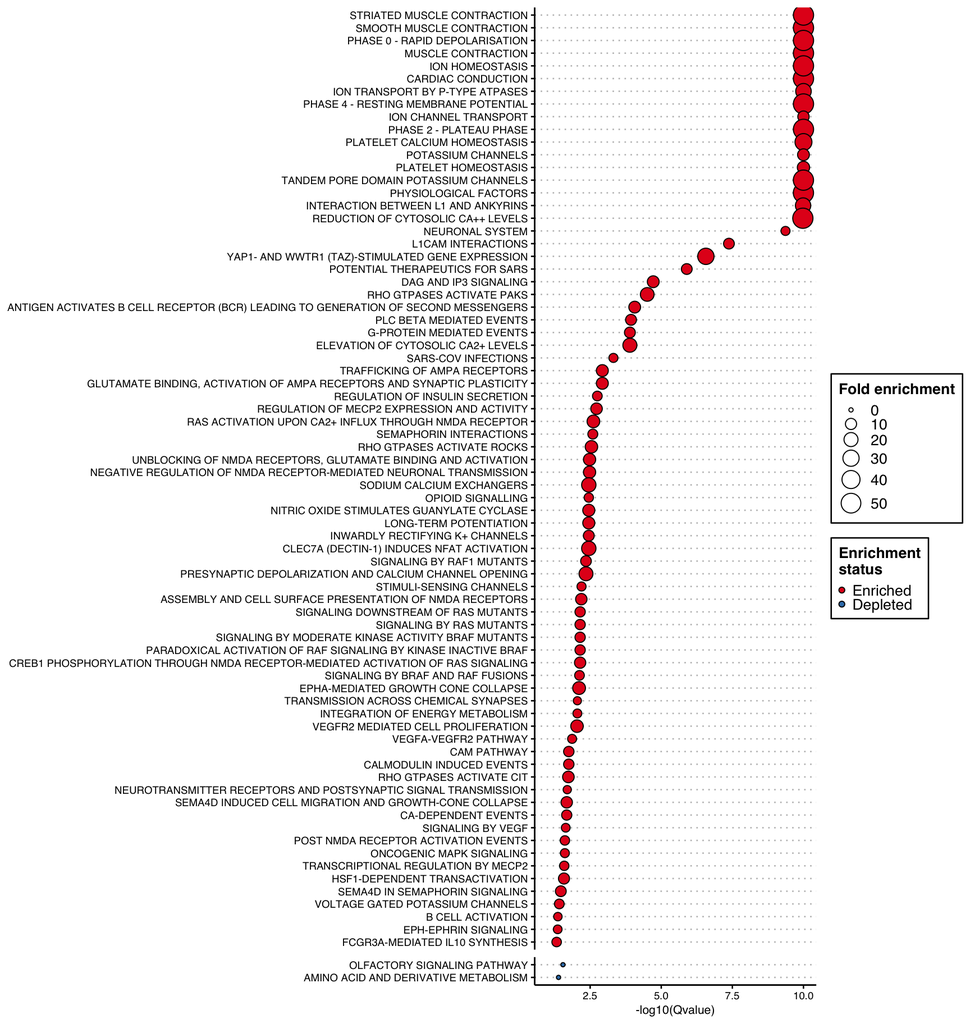

```r
fedupPlot <- fedupRes[which(fedupRes$qvalue < 0.05),]
fedupPlot$log10qvalue <- -log10(fedupPlot$qvalue + 1e-10) # -log10(qvalue)
fedupPlot$pathway <- gsub("\\%.*", "", fedupPlot$pathway) # clean names

p <- plotDotPlot(
  df = fedupPlot,
  xVar = "log10qvalue",
  yVar = "pathway",
  xLab = "-log10(Qvalue)",
  fillVar = "status",
  fillLab = "Enrichment\nstatus",
  sizeVar = "fold_enrichment",
  sizeLab = "Fold enrichment"
)

p <- p + # facet by status to separate enriched and depleted pathways
  ggplot2::facet_grid("status", scales = "free", space = "free") +
  ggplot2::theme(strip.text.y = ggplot2::element_blank())
print(p)
```

Look at all those chick… enrichments! This is a bit overwhelming, isn’t it? How do we interpret these 76 seemingly redundant pathways in a way that doesn’t hurt our tired brains even more? Oh I know, let’s use EnrichmentMap!

First, make sure to have [Cytoscape](https://cytoscape.org/download.html) downloaded and and open on your computer. You’ll also need to install the [EnrichmentMap](http://apps.cytoscape.org/apps/enrichmentmap) and [AutoAnnotate](http://apps.cytoscape.org/apps/autoannotate) apps.

Then format results for compatibility with EnrichmentMap with `writeFemap`:

```r
resultsFile <- tempfile("fedupRes", fileext = ".txt")
writeFemap(fedupRes, resultsFile)
```

```
#> Wrote out Cytoscape-formatted FEDUP results file to /var/folders/mh/_0z2r5zj3k75yhtgm6l7xy3m0000gn/T//RtmpLOV4gU/fedupResce044a714fbc.txt
```

Prepare a pathway annotation file (`gmt` format) from the pathway list you passed to `runFedup` using the `writePathways` function (you don’t need to run this function if your pathway annotations are already in `gmt` format, but it doesn’t hurt to make sure):

```r
gmtFile <- tempfile("pathwaysGMT", fileext = ".gmt")
writePathways(pathwaysGMT, gmtFile)
```

```
#> Wrote out pathway gmt file to /var/folders/mh/_0z2r5zj3k75yhtgm6l7xy3m0000gn/T//RtmpLOV4gU/pathwaysGMTce0431af69ac.gmt
```

Cytoscape is open right? If so, run these lines and let the `plotFemap` magic happen:

```
#> You are connected to Cytoscape!
#> Building the network
#> Setting network chart data
#> Annotating the network using AutoAnnotate
#> Applying a force-directed network layout
#> Drawing out network to /var/folders/mh/_0z2r5zj3k75yhtgm6l7xy3m0000gn/T//RtmpLOV4gU/FEDUP_EMce0420648847.png
#>                                                                                   file
#> "/var/folders/mh/_0z2r5zj3k75yhtgm6l7xy3m0000gn/T/RtmpLOV4gU/FEDUP_EMce0420648847.png"
```

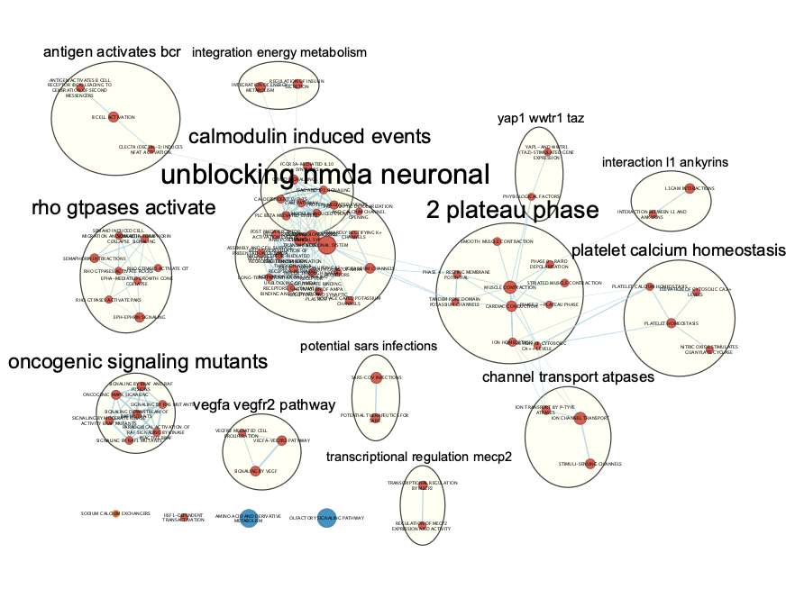

```r
netFile <- tempfile("FEDUP_EM", fileext = ".png")
plotFemap(
  gmtFile = gmtFile,
  resultsFile = resultsFile,
  qvalue = 0.05,
  netName = "FEDUP_EM",
  netFile = netFile
)
```

After some manual rearrangement of the annotated pathway clusters, this is the resulting EnrichmentMap we get from our `FEDUP` results. Much better!

## Manual input

Supply `FEDUP` with your own custom pathway annotations, eg. from an excel file:

```r
pathwayFile <- system.file("extdata", "SAFE_terms.xlsx", package = "FEDUP")
```

Take a look at the raw data structure:

```r
pathways <- openxlsx::read.xlsx(pathwayFile)
str(pathways)
```

```
#> 'data.frame':    4762 obs. of  5 variables:
#>  $ Enriched.GO.IDs    : chr  "GO:0002181" "GO:0002181" "GO:0002181" "GO:0002181" ...
#>  $ Enriched.GO.names  : chr  "cytoplasmic translation" "cytoplasmic translation" "cytoplasmic translation" "cytoplasmic translation" ...
#>  $ Network.Region.name: chr  "Ribosome biogenesis" "Ribosome biogenesis" "Ribosome biogenesis" "Ribosome biogenesis" ...
#>  $ ORF.ID             : chr  "YJL190C" "YHL033C" "YBR101C" "YOL040C" ...
#>  $ Gene.ID            : chr  "RPS22A" "RPL8A" "FES1" "RPS15" ...
```

We see these pathways are in the form of a dataframe, with pathway IDs stored in the `Enriched.GO.names` column and gene IDs in the `Gene.ID` column. Now use the `readPathways` function to convert this to list format:

```r
pathways <- readPathways(
    pathwayFile = pathwayFile,
    pathwayCol = "Enriched.GO.names",
    geneCol = "Gene.ID"
)
```

```
#> Pathway file: SAFE_terms.xlsx
#>  => n total pathways: 30
#>  => n pathways (1-Inf): 30
```

```r
str(head(pathways))
```

```
#> List of 6
#>  $ carbohydrate metabolic process      : chr [1:195] "SNF2" "GPM1" "GUT2" "TPI1" ...
#>  $ cell wall organization or biogenesis: chr [1:198] "HRD1" "GSC2" "PIR3" "PKH2" ...
#>  $ chromosome segregation              : chr [1:202] "BIM1" "MUS81" "BIR1" "SPO22" ...
#>  $ cytoplasmic translation             : chr [1:180] "RPS22A" "RPL8A" "FES1" "RPS15" ...
#>  $ DNA recombination                   : chr [1:179] "CST9" "ESC2" "SPO16" "SNF2" ...
#>  $ DNA replication                     : chr [1:139] "POL1" "SLD3" "SIN3" "SNF2" ...
```

Let’s use the `DNA replication` pathway as our `testGene` set and the entire set of unique `pathways` genes as our `backgroudGene` set:

```r
testGene <- pathways[["DNA replication"]]
backgroundGene <- unique(as.character(unlist(pathways)))
str(testGene)
```

```
#>  chr [1:139] "POL1" "SLD3" "SIN3" "SNF2" "FKH2" "CHD1" "MMS1" "HOG1" "MCM6" ...
```

```r
str(backgroundGene)
```

```
#>  chr [1:2638] "SNF2" "GPM1" "GUT2" "TPI1" "MAL32" "FBP26" "GCY1" "IMA2" ...
```

Now use `runFedup` on the data:

```r
fedupRes <- runFedup(testGene, backgroundGene, pathways)
```

```
#> Data input:
#>  => 139 test genes
#>  => 2638 background genes
#>  => 30 pathawys
#> You did it! FEDUP ran successfully, feeling pretty good huh?
```

```r
print(head(fedupRes[which(fedupRes$status == "Enriched"),]))
```

```
#>                     pathway size real_frac expected_frac fold_enrichment
#> 1:          DNA replication  139 100.00000      5.269143       18.978417
#> 2:        DNA recombination  179  35.25180      6.785444        5.195209
#> 3: regulation of cell cycle  233  23.02158      8.832449        2.606478
#> 4:        organelle fission  301  26.61871     11.410159        2.332895
#> 5:   chromosome segregation  202  18.70504      7.657316        2.442767
#> 6:    telomere organization   78  10.07194      2.956785        3.406383
#>      status                          real_gene       pvalue       qvalue
#> 1: Enriched  POL1,SLD3,SIN3,SNF2,FKH2,CHD1,... 4.826751e-83 1.448025e-81
#> 2: Enriched SLD3,SNF2,MMS1,MCM6,DPB11,SGS1,... 5.832839e-16 8.749258e-15
#> 3: Enriched FKH2,HOG1,CLB5,DPB11,GLC7,SGS1,... 1.816630e-05 1.816630e-04
#> 4: Enriched CLB5,GLC7,SGS1,MMS22,POL2,MSH2,... 4.745047e-05 3.558785e-04
#> 5: Enriched GLC7,SGS1,MMS22,POL2,RFC5,BRN1,... 2.217013e-04 9.501485e-04
#> 6: Enriched  SGS1,PIF1,RFA2,ELG1,ECO1,RIF1,... 2.787840e-04 1.045440e-03
```

```r
print(head(fedupRes[which(fedupRes$status == "Depleted"),]))
```

```
#>                                 pathway size real_frac expected_frac
#> 1:              Golgi vesicle transport  191 0.0000000      7.240334
#> 2:              cytoplasmic translation  180 0.0000000      6.823351
#> 3:                 response to chemical  431 5.0359712     16.338135
#> 4: cell wall organization or biogenesis  198 0.7194245      7.505686
#> 5:                            signaling  244 2.1582734      9.249431
#> 6:            mitochondrial translation  128 0.7194245      4.852161
#>    fold_enrichment   status                          real_gene       pvalue
#> 1:      0.00000000 Depleted                                    0.0001279608
#> 2:      0.00000000 Depleted                                    0.0001977501
#> 3:      0.30823416 Depleted HOG1,GLC7,FKH1,MET30,NTG1,MHR1,... 0.0007324462
#> 4:      0.09585059 Depleted                               BMH2 0.0013533148
#> 5:      0.23334120 Depleted                     HOG1,PPS1,BMH2 0.0041128956
#> 6:      0.14826888 Depleted                               MHR1 0.0197011225
#>          qvalue
#> 1: 0.0007677650
#> 2: 0.0009501485
#> 3: 0.0024414874
#> 4: 0.0036908586
#> 5: 0.0102822391
#> 6: 0.0447513261
```

Run through `plotDotPlot` to visualize:

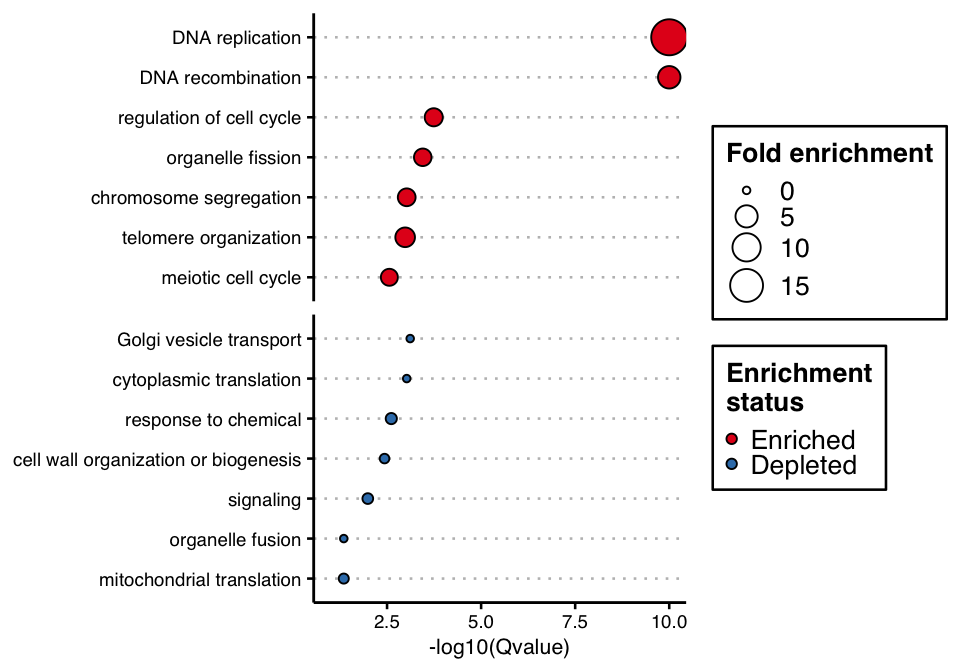

```r
fedupPlot <- fedupRes[which(fedupRes$qvalue < 0.05),]
fedupPlot$log10qvalue <- -log10(fedupPlot$qvalue + 1e-10) # log10(qvalue)
fedupPlot$pathway <- gsub("\\%.*", "", fedupPlot$pathway) # clean names

p <- plotDotPlot(
  df = fedupPlot,
  xVar = "log10qvalue",
  yVar = "pathway",
  xLab = "-log10(Qvalue)",
  fillVar = "status",
  fillLab = "Enrichment\nstatus",
  sizeVar = "fold_enrichment",
  sizeLab = "Fold enrichment"
)

p <- p + # facet by status to separate enriched and depleted pathways
  ggplot2::facet_grid("status", scales = "free", space = "free") +
  ggplot2::theme(strip.text.y = ggplot2::element_blank())
print(p)
```

# Versioning

For the versions available, see the [tags on this repo](https://github.com/rosscm/FEDUP/tags).